# 3. Logistic regression analysis

The purpose of this analysis is to study the relationships between high/low alcohol consumption and some of the other variables in the data.

The preceding data wrangling exercise is available [here.](https://github.com/palsola/IODS-project/blob/master/data/create_%20alc.R)

```
## [1] "Mon Nov 16 09:37:04 2020"
```

## Hypotheses

For this exercise, I chose 4 variables in the data that could have a relationship with alcohol consumption: quality of family relationships, number of school absences, current health status and sex. Hypotheses for each are as follows:

1. Quality of family relationships are negatively associated with alcohol consumption, i.e., the better the relationship, the less likely is high alcohol consumption.
2. Number of school absences are positively associated with alcohol consumption, i.e., the more absences, the more likely is high alcohol consumption.
3. Current health status is negatively associated with alcohol consumption, i.e., the better the health, the less likely is high alcohol consumption.
4. I am adding sex to the model mostly to control for its effects, but I also assume that male sex is positively associated with high alcohol consumption.

## Exploration of data

```r
students <- read.csv("C:/Users/minttu/R projects/IODS-project/data/students.csv")

# access the dplyr library
library(dplyr)
colnames(students)
```

```
##  [1] "school"     "sex"        "age"        "address"    "famsize"
##  [6] "Pstatus"    "Medu"       "Fedu"       "Mjob"       "Fjob"
## [11] "reason"     "nursery"    "internet"   "guardian"   "traveltime"
## [16] "studytime"  "failures"   "schoolsup"  "famsup"     "paid"
## [21] "activities" "higher"     "romantic"   "famrel"     "freetime"
## [26] "goout"      "Dalc"       "Walc"       "health"     "absences"
## [31] "G1"         "G2"         "G3"         "alc_use"    "high_use"
```

```r
keep_columns <- c("sex","famrel","health", "absences", "high_use")
alc <- select(students, one_of(keep_columns))
```

The whole dataset used for this exercise has 382 observations of 35 variables. For this exercise I will be using a subset with 382 observations of 5 variables.

Below is a summary table of all the variables as well as their bar plots. All variables except for sex seem to be skewed rather than normally distributed, which might affect the reliability of the logistic regression model.

```r
summary(alc)
```

```
##  sex         famrel          health         absences     high_use
##  F:198   Min.   :1.000   Min.   :1.000   Min.   : 0.0   Mode :logical
##  M:184   1st Qu.:4.000   1st Qu.:3.000   1st Qu.: 1.0   FALSE:268
##          Median :4.000   Median :4.000   Median : 3.0   TRUE :114
##          Mean   :3.937   Mean   :3.573   Mean   : 4.5
##          3rd Qu.:5.000   3rd Qu.:5.000   3rd Qu.: 6.0
##          Max.   :5.000   Max.   :5.000   Max.   :45.0
```

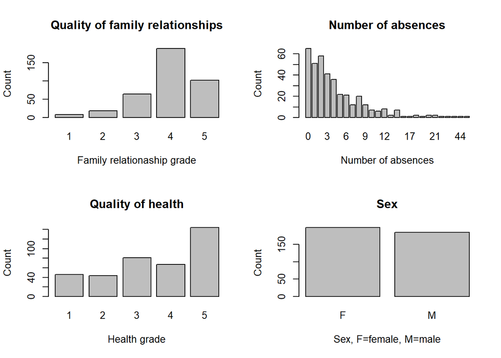

```r
par(mfrow=c(2,2))
# barplot of famrel
barplot(table(alc$famrel),
main="Quality of family relationships",
xlab="Family relationaship grade",
ylab="Count"
)

# barplot of absences
barplot(table(alc$absences),
main="Number of absences",
xlab="Number of absences",
ylab="Count"
)

# barplot of health
barplot(table(alc$health),
main="Quality of health",
xlab="Health grade",
ylab="Count"
)

# barplot of sex
barplot(table(alc$sex),
main="Sex",
xlab="Sex, F=female, M=male",
ylab="Count"
)
```

I used boxplots to explore the relationships between alcohol consumption family relations, health, and absences. I drew plots separately for females and males. In addition, I investigated the relationship between sex and alcohol consumption with cross tabulation.

Based on these, it seems that:

1. Quality of family relationships might be slightly negatively associated with alcohol consumption as hypothesized
2. Number of school absences might be positively associated with alcohol consumption as hypothesized.
3. Current health status is not associated with alcohol consumption contrary to initial hypothesis.
4. Male sex is positively associated with high alcohol consumption as hypothesized.

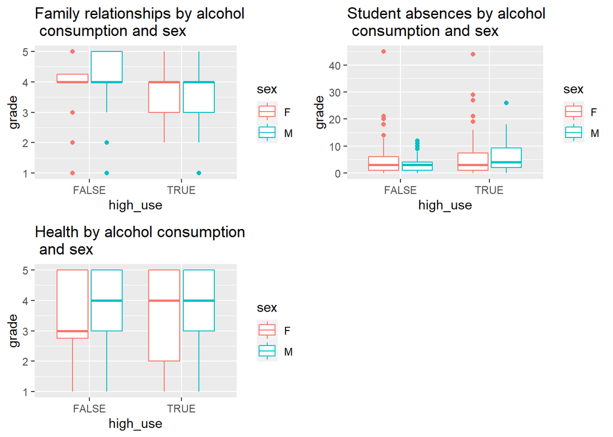

```r
# access libraries
library(ggplot2)

# a plot of high_use and family relations by sex
g1 <- ggplot(alc, aes(x = high_use, y = famrel, colour= sex)) + geom_boxplot() + ylab("grade") + ggtitle("Family relationships by alcohol \n consumption and sex")

# a plot of high_use and absences by sex
g2 <- ggplot(alc, aes(x = high_use, y = absences, colour= sex)) + geom_boxplot() + ylab("grade") + ggtitle("Student absences by alcohol \n consumption and sex")

# a plot of high_use and health by sex
g3 <- ggplot(alc, aes(x = high_use, y = health, colour= sex)) + geom_boxplot() + ylab("grade") + ggtitle("Health by alcohol consumption \n and sex")

library(gridExtra)
grid.arrange(g1, g2, g3, ncol=2)
```

```r
# a cross-tabulation of high_use and sex
table1 <- xtabs(~sex+high_use, data=alc)
ftable(table1)
```

```
##     high_use FALSE TRUE
## sex
## F              156   42
## M              112   72
```

```r
summary(table1)
```

```
## Call: xtabs(formula = ~sex + high_use, data = alc)
## Number of cases in table: 382
## Number of factors: 2
## Test for independence of all factors:
##  Chisq = 14.625, df = 1, p-value = 0.0001312
```

## Logistic regression

```r
# find the model with glm()
m <- glm(high_use ~ famrel + absences + health + sex, data = alc, family = "binomial")

# compute odds ratios (OR)
OR <- coef(m) %>% exp

# compute confidence intervals (CI)
CI <- confint(m) %>% exp

# print out the odds ratios with their confidence intervals
summary(m)
```

```
##
## Call:
## glm(formula = high_use ~ famrel + absences + health + sex, family = "binomial",
##     data = alc)
##
## Deviance Residuals:
##     Min       1Q   Median       3Q      Max
## -2.2557  -0.8609  -0.6151   1.0698   2.1157
##
## Coefficients:
##             Estimate Std. Error z value Pr(>|z|)
## (Intercept) -0.94806    0.58165  -1.630   0.1031
## famrel      -0.30625    0.12864  -2.381   0.0173 *
## absences     0.09375    0.02264   4.141 3.45e-05 ***
## health       0.08331    0.08779   0.949   0.3426
## sexM         1.00440    0.24498   4.100 4.13e-05 ***
## ---
## Signif. codes:  0 '***' 0.001 '**' 0.01 '*' 0.05 '.' 0.1 ' ' 1
##
## (Dispersion parameter for binomial family taken to be 1)
##
##     Null deviance: 465.68  on 381  degrees of freedom
## Residual deviance: 423.95  on 377  degrees of freedom
## AIC: 433.95
##
## Number of Fisher Scoring iterations: 4
```

```r
cbind(OR, CI)
```

```
##                    OR     2.5 %    97.5 %
## (Intercept) 0.3874923 0.1218232 1.2018295
## famrel      0.7362043 0.5708862 0.9470728
## absences    1.0982852 1.0527088 1.1506747
## health      1.0868775 0.9165274 1.2940911
## sexM        2.7302676 1.6999004 4.4499308
```

According to the regression model:

1. Family relationships are negatively associated with alcohol consumption (negative coefficient, p<.05, CI does not contain 1, and is <1)
2. Absences are positively associated with alcohol consumption (positive coefficient, p<0.001, CI does not contain 1, and is >1)
3. Health is not associated with alcohol consumption (p>.05, CI contains 1)
4. Male sex is positively associated with alcohol consumption (positive coefficient, p<.001, CI does not contain 1, and is >1)

Hence, support was gained for hypotheses 1,2 and 4, but not 3. Furthermore, the odds ratios show that having good family relationships is more likely to lead to low use rather than high use: the people of higher grades of family relations have 0.74 times the odds to have high alcohol use compared to lower grades. Conversely, the people with more absences have 1.09 times the odds to have high use of alcohol than people with less absences. The males have 2.73 the odds to have high alcohol use compared to females

Next, I will only use the variables that had a statistical relationship with high/low alcohol consumption, and explore the predictive power of this model.

```r
# model with sig IVs
m1 <- glm(high_use ~ famrel + absences + sex, data = alc, family = "binomial")

# predict() the probability of high_use
probabilities <- predict(m1, type = "response")

# add the predicted probabilities to 'alc'
alc <- mutate(alc, probability = probabilities)

# use the probabilities to make a prediction of high_use
alc <- mutate(alc, prediction = probability > 0.5)

# target variable versus the predictions
table(high_use = alc$high_use, prediction = alc$prediction)
```

```
##         prediction
## high_use FALSE TRUE
##    FALSE   256   12
##    TRUE     85   29
```

```r
table(high_use = alc$high_use, prediction = alc$prediction) %>% prop.table %>% addmargins
```

```
##         prediction
## high_use      FALSE       TRUE        Sum
##    FALSE 0.67015707 0.03141361 0.70157068
##    TRUE  0.22251309 0.07591623 0.29842932
##    Sum   0.89267016 0.10732984 1.00000000
```

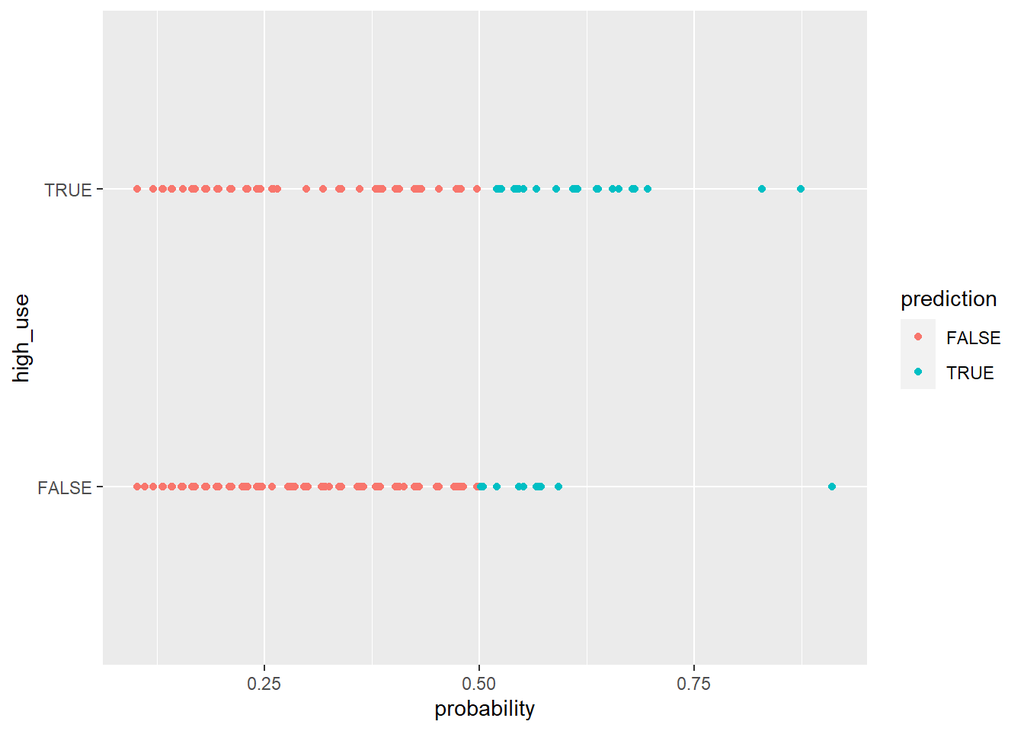

```r
# a plot of 'high_use' versus 'probability' in 'alc'
g <- ggplot(alc, aes(x = probability, y = high_use, col = prediction))
g + geom_point()
```

```r
# define a loss function (average prediction error)
loss_func <- function(class, prob) {
  n_wrong <- abs(class - prob) > 0.5
  mean(n_wrong)
}

# call loss_func to compute the average number of wrong predictions in the (training) data
loss <- loss_func(class = alc$high_use, prob = alc$probability)
```

According to the 2x2 cross tabulation of predictions versus the actual values, it seems like the model is not perfect in predicting alcohol use. Based on the cross tabulation, it is better in predicting true low use rather than true high use. The same is true when examining probabilities in cross tabulation and plot.

The average number of wrong predictions in the data is 0.2539267, which is not too bad.

## Cross validation

```r
# K-fold cross-validation
library(boot)
cv <- cv.glm(data = alc, cost = loss_func, glmfit = m1, K = 10)

# average number of wrong predictions in the cross validation
wrong_pred <- cv$delta[1]
```

The average number of wrong predictions in the cross validation is 0.2643979 which is about the same as the model introduced in DataCamp (which had about 0.26 error).

```r
#Super-Bonus: Perform cross-validation to compare the performance of different logistic regression models (= different sets of predictors). Start with a very high number of predictors and explore the changes in the training and testing errors as you move to models with less predictors. Draw a graph displaying the trends of both training and testing errors by the number of predictors in the model. (0-4 points to compensate any loss of points from the above exercises)
```

[output not shown]